# Project - Thera Bank Personal Loan Campaign

### The classification goal is to predict the likelihood of a liability customer buying personal loans.

### Domain

Banking

### Context:This case is about a bank (Thera Bank) whose management wants to explore ways of converting its liability customers to personal loan customers (while retaining them as depositors). A campaign that the bank ran last year for liability customers showed a healthy conversion rate of over 9% success. This has encouraged the retail marketing department to devise campaigns with better target marketing to increase the success ratio with a minimal budget

#### 1. Import the datasets and libraries, check datatype, statistical summary,shape,null values or incorrect imputation. (5 marks)

```python
import numpy as np
import pandas as pd
import matplotlib.pyplot as plt
%matplotlib inline
import seaborn as sns
```

```python
bkdata = pd.read_csv('Bank_Personal_Loan_Modelling.csv')
```

```python
bkdata.head()
```

|  | ID | Age | Experience | Income | ZIP Code | Family | CCAvg | Education | Mortgage | Personal Loan | Securities Account | CD Account | Online | CreditCard |
| --- | --- | --- | --- | --- | --- | --- | --- | --- | --- | --- | --- | --- | --- | --- |
| 0 | 1 | 25 | 1 | 49 | 91107 | 4 | 1.6 | 1 | 0 | 0 | 1 | 0 | 0 | 0 |
| 1 | 2 | 45 | 19 | 34 | 90089 | 3 | 1.5 | 1 | 0 | 0 | 1 | 0 | 0 | 0 |
| 2 | 3 | 39 | 15 | 11 | 94720 | 1 | 1.0 | 1 | 0 | 0 | 0 | 0 | 0 | 0 |
| 3 | 4 | 35 | 9 | 100 | 94112 | 1 | 2.7 | 2 | 0 | 0 | 0 | 0 | 0 | 0 |
| 4 | 5 | 35 | 8 | 45 | 91330 | 4 | 1.0 | 2 | 0 | 0 | 0 | 0 | 0 | 1 |

```python
bkdata.shape
```

```
(5000, 14)
```

```python
bkdata.info
```

```
<bound method DataFrame.info of         ID  Age  Experience  Income  ZIP Code  Family  CCAvg  Education  \
0        1   25           1      49     91107       4    1.6          1
1        2   45          19      34     90089       3    1.5          1
2        3   39          15      11     94720       1    1.0          1
3        4   35           9     100     94112       1    2.7          2
4        5   35           8      45     91330       4    1.0          2
...    ...  ...         ...     ...       ...     ...    ...        ...
4995  4996   29           3      40     92697       1    1.9          3
4996  4997   30           4      15     92037       4    0.4          1
4997  4998   63          39      24     93023       2    0.3          3
4998  4999   65          40      49     90034       3    0.5          2
4999  5000   28           4      83     92612       3    0.8          1

      Mortgage  Personal Loan  Securities Account  CD Account  Online  \
0            0              0                   1           0       0
```

[output cut: 25 more lines]

```python
bkdata.describe()
```

|  | ID | Age | Experience | Income | ZIP Code | Family | CCAvg | Education | Mortgage | Personal Loan | Securities Account | CD Account | Online | CreditCard |
| --- | --- | --- | --- | --- | --- | --- | --- | --- | --- | --- | --- | --- | --- | --- |
| count | 5000.000000 | 5000.000000 | 5000.000000 | 5000.000000 | 5000.000000 | 5000.000000 | 5000.000000 | 5000.000000 | 5000.000000 | 5000.000000 | 5000.000000 | 5000.00000 | 5000.000000 | 5000.000000 |
| mean | 2500.500000 | 45.338400 | 20.104600 | 73.774200 | 93152.503000 | 2.396400 | 1.937938 | 1.881000 | 56.498800 | 0.096000 | 0.104400 | 0.06040 | 0.596800 | 0.294000 |
| std | 1443.520003 | 11.463166 | 11.467954 | 46.033729 | 2121.852197 | 1.147663 | 1.747659 | 0.839869 | 101.713802 | 0.294621 | 0.305809 | 0.23825 | 0.490589 | 0.455637 |
| min | 1.000000 | 23.000000 | -3.000000 | 8.000000 | 9307.000000 | 1.000000 | 0.000000 | 1.000000 | 0.000000 | 0.000000 | 0.000000 | 0.00000 | 0.000000 | 0.000000 |
| 25% | 1250.750000 | 35.000000 | 10.000000 | 39.000000 | 91911.000000 | 1.000000 | 0.700000 | 1.000000 | 0.000000 | 0.000000 | 0.000000 | 0.00000 | 0.000000 | 0.000000 |
| 50% | 2500.500000 | 45.000000 | 20.000000 | 64.000000 | 93437.000000 | 2.000000 | 1.500000 | 2.000000 | 0.000000 | 0.000000 | 0.000000 | 0.00000 | 1.000000 | 0.000000 |
| 75% | 3750.250000 | 55.000000 | 30.000000 | 98.000000 | 94608.000000 | 3.000000 | 2.500000 | 3.000000 | 101.000000 | 0.000000 | 0.000000 | 0.00000 | 1.000000 | 1.000000 |
| max | 5000.000000 | 67.000000 | 43.000000 | 224.000000 | 96651.000000 | 4.000000 | 10.000000 | 3.000000 | 635.000000 | 1.000000 | 1.000000 | 1.00000 | 1.000000 | 1.000000 |

```python
bkdata.isnull().values.any()
```

```
False
```

#### 2. EDA: Study the data distribution in each attribute and target variable, share your findings (20 marks)

```python
bkdata.drop(['ID'], axis=1, inplace=True)
```

```python
bkdata.head()
```

|  | Age | Experience | Income | ZIP Code | Family | CCAvg | Education | Mortgage | Personal Loan | Securities Account | CD Account | Online | CreditCard |
| --- | --- | --- | --- | --- | --- | --- | --- | --- | --- | --- | --- | --- | --- |
| 0 | 25 | 1 | 49 | 91107 | 4 | 1.6 | 1 | 0 | 0 | 1 | 0 | 0 | 0 |
| 1 | 45 | 19 | 34 | 90089 | 3 | 1.5 | 1 | 0 | 0 | 1 | 0 | 0 | 0 |
| 2 | 39 | 15 | 11 | 94720 | 1 | 1.0 | 1 | 0 | 0 | 0 | 0 | 0 | 0 |
| 3 | 35 | 9 | 100 | 94112 | 1 | 2.7 | 2 | 0 | 0 | 0 | 0 | 0 | 0 |
| 4 | 35 | 8 | 45 | 91330 | 4 | 1.0 | 2 | 0 | 0 | 0 | 0 | 0 | 1 |

```python
bkdata['Age'].unique()
```

```
array([25, 45, 39, 35, 37, 53, 50, 34, 65, 29, 48, 59, 67, 60, 38, 42, 46,
       55, 56, 57, 44, 36, 43, 40, 30, 31, 51, 32, 61, 41, 28, 49, 47, 62,
       58, 54, 33, 27, 66, 24, 52, 26, 64, 63, 23])
```

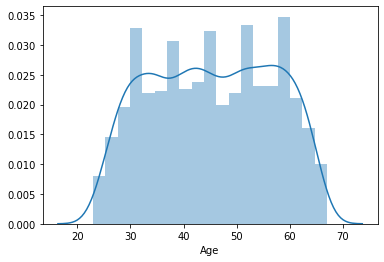

```python
sns.distplot(bkdata['Age']);
```

```python
bkdata['Income'].unique()
```

```
array([ 49,  34,  11, 100,  45,  29,  72,  22,  81, 180, 105, 114,  40,
       112, 130, 193,  21,  25,  63,  62,  43, 152,  83, 158,  48, 119,
        35,  41,  18,  50, 121,  71, 141,  80,  84,  60, 132, 104,  52,
       194,   8, 131, 190,  44, 139,  93, 188,  39, 125,  32,  20, 115,
        69,  85, 135,  12, 133,  19,  82, 109,  42,  78,  51, 113, 118,
        64, 161,  94,  15,  74,  30,  38,   9,  92,  61,  73,  70, 149,
        98, 128,  31,  58,  54, 124, 163,  24,  79, 134,  23,  13, 138,
       171, 168,  65,  10, 148, 159, 169, 144, 165,  59,  68,  91, 172,
        55, 155,  53,  89,  28,  75, 170, 120,  99, 111,  33, 129, 122,
       150, 195, 110, 101, 191, 140, 153, 173, 174,  90, 179, 145, 200,
       183, 182,  88, 160, 205, 164,  14, 175, 103, 108, 185, 204, 154,
       102, 192, 202, 162, 142,  95, 184, 181, 143, 123, 178, 198, 201,
       203, 189, 151, 199, 224, 218])
```

```python
bkdata['ZIP Code'].nunique()
```

```
467
```

```python
bkdata['Family'].unique()
```

```
array([4, 3, 1, 2])
```

```python
bkdata['CCAvg'].unique()
```

```
array([ 1.6 ,  1.5 ,  1.  ,  2.7 ,  0.4 ,  0.3 ,  0.6 ,  8.9 ,  2.4 ,
        0.1 ,  3.8 ,  2.5 ,  2.  ,  4.7 ,  8.1 ,  0.5 ,  0.9 ,  1.2 ,
        0.7 ,  3.9 ,  0.2 ,  2.2 ,  3.3 ,  1.8 ,  2.9 ,  1.4 ,  5.  ,
        2.3 ,  1.1 ,  5.7 ,  4.5 ,  2.1 ,  8.  ,  1.7 ,  0.  ,  2.8 ,
        3.5 ,  4.  ,  2.6 ,  1.3 ,  5.6 ,  5.2 ,  3.  ,  4.6 ,  3.6 ,
        7.2 ,  1.75,  7.4 ,  2.67,  7.5 ,  6.5 ,  7.8 ,  7.9 ,  4.1 ,
        1.9 ,  4.3 ,  6.8 ,  5.1 ,  3.1 ,  0.8 ,  3.7 ,  6.2 ,  0.75,
        2.33,  4.9 ,  0.67,  3.2 ,  5.5 ,  6.9 ,  4.33,  7.3 ,  4.2 ,
        4.4 ,  6.1 ,  6.33,  6.6 ,  5.3 ,  3.4 ,  7.  ,  6.3 ,  8.3 ,
        6.  ,  1.67,  8.6 ,  7.6 ,  6.4 , 10.  ,  5.9 ,  5.4 ,  8.8 ,
        1.33,  9.  ,  6.7 ,  4.25,  6.67,  5.8 ,  4.8 ,  3.25,  5.67,
        8.5 ,  4.75,  4.67,  3.67,  8.2 ,  3.33,  5.33,  9.3 ,  2.75])
```

```python
bkdata['Education'].unique()
```

```
array([1, 2, 3])
```

```python
bkdata['Mortgage'].nunique()
```

```
347
```

```python
bkdata['Personal Loan'].unique()
```

```
array([0, 1])
```

```python
(bkdata.Mortgage==0).sum()
```

```
3462
```

```python
bkdata['Mortgage'].mean()
```

```
56.4988
```

```python
(bkdata.CreditCard==0).sum()
```

```
3530
```

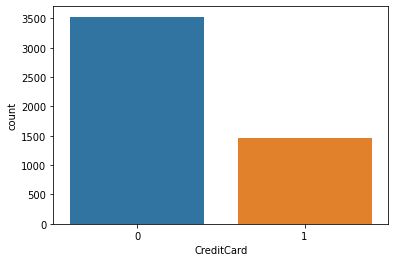

```python
sns.countplot(bkdata['CreditCard']);
```

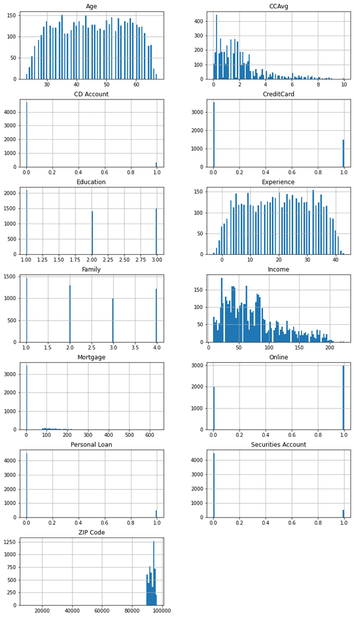

```python
columns = list(bkdata)[:] # Excluding Outcome column which has only
bkdata[columns].hist(stacked=False, bins=100, figsize=(12,45), layout=(14,2));
```

```python
bkdata.corr()
```

|  | Age | Experience | Income | ZIP Code | Family | CCAvg | Education | Mortgage | Personal Loan | Securities Account | CD Account | Online | CreditCard |
| --- | --- | --- | --- | --- | --- | --- | --- | --- | --- | --- | --- | --- | --- |
| Age | 1.000000 | 0.994215 | -0.055269 | -0.029216 | -0.046418 | -0.052012 | 0.041334 | -0.012539 | -0.007726 | -0.000436 | 0.008043 | 0.013702 | 0.007681 |
| Experience | 0.994215 | 1.000000 | -0.046574 | -0.028626 | -0.052563 | -0.050077 | 0.013152 | -0.010582 | -0.007413 | -0.001232 | 0.010353 | 0.013898 | 0.008967 |
| Income | -0.055269 | -0.046574 | 1.000000 | -0.016410 | -0.157501 | 0.645984 | -0.187524 | 0.206806 | 0.502462 | -0.002616 | 0.169738 | 0.014206 | -0.002385 |
| ZIP Code | -0.029216 | -0.028626 | -0.016410 | 1.000000 | 0.011778 | -0.004061 | -0.017377 | 0.007383 | 0.000107 | 0.004704 | 0.019972 | 0.016990 | 0.007691 |
| Family | -0.046418 | -0.052563 | -0.157501 | 0.011778 | 1.000000 | -0.109275 | 0.064929 | -0.020445 | 0.061367 | 0.019994 | 0.014110 | 0.010354 | 0.011588 |
| CCAvg | -0.052012 | -0.050077 | 0.645984 | -0.004061 | -0.109275 | 1.000000 | -0.136124 | 0.109905 | 0.366889 | 0.015086 | 0.136534 | -0.003611 | -0.006689 |
| Education | 0.041334 | 0.013152 | -0.187524 | -0.017377 | 0.064929 | -0.136124 | 1.000000 | -0.033327 | 0.136722 | -0.010812 | 0.013934 | -0.015004 | -0.011014 |
| Mortgage | -0.012539 | -0.010582 | 0.206806 | 0.007383 | -0.020445 | 0.109905 | -0.033327 | 1.000000 | 0.142095 | -0.005411 | 0.089311 | -0.005995 | -0.007231 |
| Personal Loan | -0.007726 | -0.007413 | 0.502462 | 0.000107 | 0.061367 | 0.366889 | 0.136722 | 0.142095 | 1.000000 | 0.021954 | 0.316355 | 0.006278 | 0.002802 |
| Securities Account | -0.000436 | -0.001232 | -0.002616 | 0.004704 | 0.019994 | 0.015086 | -0.010812 | -0.005411 | 0.021954 | 1.000000 | 0.317034 | 0.012627 | -0.015028 |
| CD Account | 0.008043 | 0.010353 | 0.169738 | 0.019972 | 0.014110 | 0.136534 | 0.013934 | 0.089311 | 0.316355 | 0.317034 | 1.000000 | 0.175880 | 0.278644 |
| Online | 0.013702 | 0.013898 | 0.014206 | 0.016990 | 0.010354 | -0.003611 | -0.015004 | -0.005995 | 0.006278 | 0.012627 | 0.175880 | 1.000000 | 0.004210 |
| CreditCard | 0.007681 | 0.008967 | -0.002385 | 0.007691 | 0.011588 | -0.006689 | -0.011014 | -0.007231 | 0.002802 | -0.015028 | 0.278644 | 0.004210 | 1.000000 |

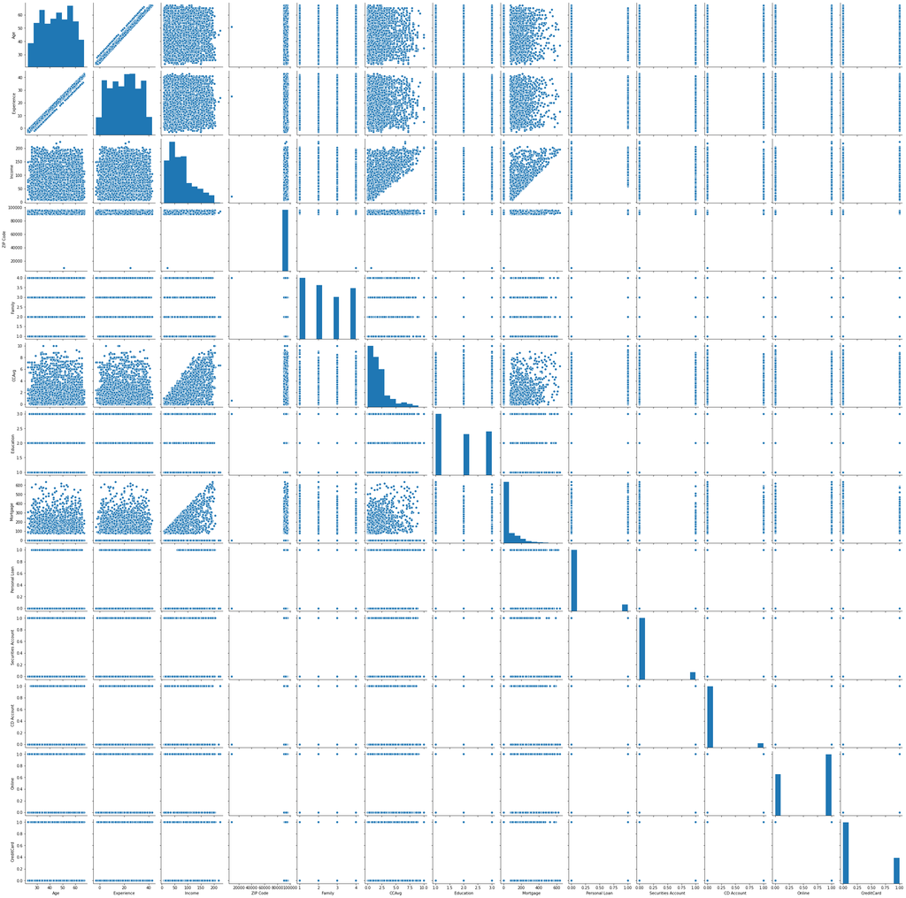

```python
sns.pairplot(bkdata);
```

```python
bkdata.drop(['ZIP Code'], axis=1, inplace=True) #ZIP Code doesn't provide much insight
```

```python
bkdata.head(10)
```

|  | Age | Experience | Income | Family | CCAvg | Education | Mortgage | Personal Loan | Securities Account | CD Account | Online | CreditCard |
| --- | --- | --- | --- | --- | --- | --- | --- | --- | --- | --- | --- | --- |
| 0 | 25 | 1 | 49 | 4 | 1.6 | 1 | 0 | 0 | 1 | 0 | 0 | 0 |
| 1 | 45 | 19 | 34 | 3 | 1.5 | 1 | 0 | 0 | 1 | 0 | 0 | 0 |
| 2 | 39 | 15 | 11 | 1 | 1.0 | 1 | 0 | 0 | 0 | 0 | 0 | 0 |
| 3 | 35 | 9 | 100 | 1 | 2.7 | 2 | 0 | 0 | 0 | 0 | 0 | 0 |
| 4 | 35 | 8 | 45 | 4 | 1.0 | 2 | 0 | 0 | 0 | 0 | 0 | 1 |
| 5 | 37 | 13 | 29 | 4 | 0.4 | 2 | 155 | 0 | 0 | 0 | 1 | 0 |
| 6 | 53 | 27 | 72 | 2 | 1.5 | 2 | 0 | 0 | 0 | 0 | 1 | 0 |
| 7 | 50 | 24 | 22 | 1 | 0.3 | 3 | 0 | 0 | 0 | 0 | 0 | 1 |
| 8 | 35 | 10 | 81 | 3 | 0.6 | 2 | 104 | 0 | 0 | 0 | 1 | 0 |
| 9 | 34 | 9 | 180 | 1 | 8.9 | 3 | 0 | 1 | 0 | 0 | 0 | 0 |

### 3. Split the data into training and test set in the ratio of 70:30 respectively (5 marks)

```python
n_true = len(bkdata.loc[bkdata['Personal Loan'] == True])
n_false = len(bkdata.loc[bkdata['Personal Loan'] == False])
print("Number of people purchased personal loan: {0} ({1:2.2f}%)".format(n_true, (n_true / (n_true + n_false)) * 100 ))
print("Number of people did not purchase personal loan: {0} ({1:2.2f}%)".format(n_false, (n_false / (n_true + n_false)) * 100))
```

```
Number of people purchased personal loan: 480 (9.60%)
Number of people did not purchase personal loan: 4520 (90.40%)
```

```python
from sklearn.model_selection import train_test_split

X = bkdata.drop('Personal Loan',axis=1)     # Predictor feature columns (8 X m)
Y = bkdata['Personal Loan']   # Predicted class (1=True, 0=False) (1 X m)

X_train, X_test, Y_train, Y_test = train_test_split(X, Y, test_size=0.3, random_state=1)
# 1 is just any random seed number

X_train.head()
```

|  | Age | Experience | Income | Family | CCAvg | Education | Mortgage | Securities Account | CD Account | Online | CreditCard |
| --- | --- | --- | --- | --- | --- | --- | --- | --- | --- | --- | --- |
| 1334 | 47 | 22 | 35 | 2 | 1.3 | 1 | 0 | 0 | 0 | 1 | 0 |
| 4768 | 38 | 14 | 39 | 1 | 2.0 | 2 | 0 | 0 | 0 | 1 | 0 |
| 65 | 59 | 35 | 131 | 1 | 3.8 | 1 | 0 | 0 | 0 | 1 | 1 |
| 177 | 29 | 3 | 65 | 4 | 1.8 | 2 | 244 | 0 | 0 | 0 | 0 |
| 4489 | 39 | 13 | 21 | 3 | 0.2 | 2 | 0 | 0 | 0 | 1 | 0 |

```python
print("{0:0.2f}% data is in training set".format((len(X_train)/len(bkdata.index)) * 100))
print("{0:0.2f}% data is in test set".format((len(X_test)/len(bkdata.index)) * 100))
```

```
70.00% data is in training set
30.00% data is in test set
```

```python
print("Original Loan Values   : {0} ({1:0.2f}%)".format(len(bkdata.loc[bkdata['Personal Loan'] == 1]), (len(bkdata.loc[bkdata['Personal Loan'] == 1])/len(bkdata.index)) * 100))
print("Original No Loan Values: {0} ({1:0.2f}%)".format(len(bkdata.loc[bkdata['Personal Loan'] == 0]), (len(bkdata.loc[bkdata['Personal Loan'] == 0])/len(bkdata.index)) * 100))
print("")
print("Training Loan Values   : {0} ({1:0.2f}%)".format(len(Y_train[Y_train[:] == 1]), (len(Y_train[Y_train[:] == 1])/len(Y_train)) * 100))
print("Training No Loan Values: {0} ({1:0.2f}%)".format(len(Y_train[Y_train[:] == 0]), (len(Y_train[Y_train[:] == 0])/len(Y_train)) * 100))
print("")
print("Test Loan Values       : {0} ({1:0.2f}%)".format(len(Y_test[Y_test[:] == 1]), (len(Y_test[Y_test[:] == 1])/len(Y_test)) * 100))
print("Test No Loan Values    : {0} ({1:0.2f}%)".format(len(Y_test[Y_test[:] == 0]), (len(Y_test[Y_test[:] == 0])/len(Y_test)) * 100))
print("")
```

```
Original Loan Values   : 480 (9.60%)
Original No Loan Values: 4520 (90.40%)

Training Loan Values   : 331 (9.46%)
Training No Loan Values: 3169 (90.54%)

Test Loan Values       : 149 (9.93%)
Test No Loan Values    : 1351 (90.07%)
```

### 4. Use Logistic Regression model to predict the number of a customers buying personal loans. Print all the metrics related for evaluating the model performance (15 marks)

```python
from sklearn import metrics

from sklearn.linear_model import LogisticRegression

# Fit the model on train
model = LogisticRegression(solver="liblinear")
model.fit(X_train, Y_train)
#predict on test
Y_predict = model.predict(X_test)


coef_df = pd.DataFrame(model.coef_)
coef_df['intercept'] = model.intercept_
print(coef_df)
```

```
          0         1         2         3         4         5         6  \
0 -0.406316  0.404924  0.049147  0.651681  0.162409  1.655882  0.000795

          7         8         9        10  intercept
0 -0.907322  3.262492 -0.576244 -1.005814  -2.378255
```

```python
model_score = model.score(X_test, Y_test)
print(model_score)
```

```
0.9453333333333334
```

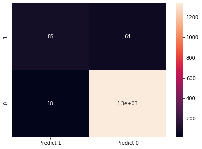

```python
cm=metrics.confusion_matrix(Y_test, Y_predict, labels=[1, 0])

df_cm = pd.DataFrame(cm, index = [i for i in ["1","0"]],
                  columns = [i for i in ["Predict 1","Predict 0"]])
plt.figure(figsize = (7,5))
sns.heatmap(df_cm, annot=True)
```

The confusion matrix

True Positives (TP): we correctly predicted that customers bought personal loan 85

True Negatives (TN): we correctly predicted that they didn't buy personal loan 1333

False Positives (FP): we incorrectly predicted personal loan (a "Type I error") 18 Falsely predict positive Type I error

False Negatives (FN): we incorrectly predicted no personal loan (a "Type II error") 64 Falsely predict negative Type II error

### 5. Give your reasoning on how can the model perform better? (10 marks) Hint: Check parameter

```
training set score of lgr1: 0.952000

test set score of lgr1: 0.945333

training set score of lgr100: 0.953143

test set score of lgr100: 0.947333

training set score of lgr10: 0.953143

test set score of lgr10: 0.947333

training set score of lgr01: 0.950286

test set score of lgr01: 0.946667

training set score of lgr001: 0.938000

test set score of lgr001: 0.934667
```

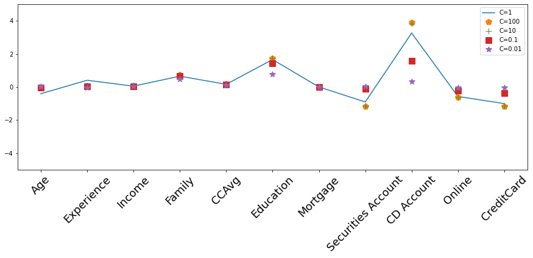

```python
print('\n'"training set score of lgr1: %f" % model.score(X_train, Y_train))
print('\n'"test set score of lgr1: %f" % model.score(X_test, Y_test))

######increase C to 100#####
lgr100=LogisticRegression(C=100, max_iter=7000).fit(X_train,Y_train)
print('\n'"training set score of lgr100: %f" % lgr100.score(X_train, Y_train))
print('\n'"test set score of lgr100: %f" % lgr100.score(X_test, Y_test))

######increase C to 10#####
lgr10=LogisticRegression(C=10, max_iter=7000).fit(X_train,Y_train)
print('\n'"training set score of lgr10: %f" % lgr100.score(X_train, Y_train))
print('\n'"test set score of lgr10: %f" % lgr100.score(X_test, Y_test))

######decrease C to 0.1#####
lgr01=LogisticRegression(C=0.1, max_iter=7000).fit(X_train,Y_train)
print('\n'"training set score of lgr01: %f" % lgr01.score(X_train, Y_train))
print('\n'"test set score of lgr01: %f" % lgr01.score(X_test, Y_test))

######decrease C to 0.01#####
lgr001=LogisticRegression(C=0.01, max_iter=7000).fit(X_train,Y_train)
print('\n'"training set score of lgr001: %f" % lgr001.score(X_train, Y_train))
print('\n'"test set score of lgr001: %f" % lgr001.score(X_test, Y_test))

import matplotlib.pyplot as plt
plt.figure(figsize=(15,5))
plt.plot(model.coef_.T,'-', markersize=10, label='C=1')
plt.plot(lgr100.coef_.T,'p',markersize=10, label='C=100')
plt.plot(lgr10.coef_.T,'+', markersize=10, label='C=10')
plt.plot(lgr01.coef_.T,'s', markersize=10, label='C=0.1')
plt.plot(lgr001.coef_.T,'*',markersize=10, label='C=0.01')
plt.xticks(range(X.shape[1]),X.columns,rotation=45, fontsize=18 )

plt.ylim(-5,5)
plt.legend()
plt.show()
```

### 6. Give Business understanding of your model? (5 marks)

With the model, the bank can evaluate the possiblity of getting personal loans for new customers and old customers without personal loan yet. It can then do targeted advertising to certain groups of customers.